# Project Python Foundations: FoodHub Data Analysis

**Marks: 60**

### Context

The number of restaurants in New York is increasing day by day. Lots of students and busy professionals rely on those restaurants due to their hectic lifestyles. Online food delivery service is a great option for them. It provides them with good food from their favorite restaurants. A food aggregator company FoodHub offers access to multiple restaurants through a single smartphone app.

The app allows the restaurants to receive a direct online order from a customer. The app assigns a delivery person from the company to pick up the order after it is confirmed by the restaurant. The delivery person then uses the map to reach the restaurant and waits for the food package. Once the food package is handed over to the delivery person, he/she confirms the pick-up in the app and travels to the customer's location to deliver the food. The delivery person confirms the drop-off in the app after delivering the food package to the customer. The customer can rate the order in the app. The food aggregator earns money by collecting a fixed margin of the delivery order from the restaurants.

### Objective

The food aggregator company has stored the data of the different orders made by the registered customers in their online portal. They want to analyze the data to get a fair idea about the demand of different restaurants which will help them in enhancing their customer experience. Suppose you are hired as a Data Scientist in this company and the Data Science team has shared some of the key questions that need to be answered. Perform the data analysis to find answers to these questions that will help the company to improve the business.

### Data Description

The data contains the different data related to a food order. The detailed data dictionary is given below.

### Data Dictionary

- order_id: Unique ID of the order
- customer_id: ID of the customer who ordered the food
- restaurant_name: Name of the restaurant
- cuisine_type: Cuisine ordered by the customer
- cost: Cost of the order
- day_of_the_week: Indicates whether the order is placed on a weekday or weekend (The weekday is from Monday to Friday and the weekend is Saturday and Sunday)
- rating: Rating given by the customer out of 5
- food_preparation_time: Time (in minutes) taken by the restaurant to prepare the food. This is calculated by taking the difference between the timestamps of the restaurant's order confirmation and the delivery person's pick-up confirmation.
- delivery_time: Time (in minutes) taken by the delivery person to deliver the food package. This is calculated by taking the difference between the timestamps of the delivery person's pick-up confirmation and drop-off information

### Let us start by importing the required libraries

```python
# import libraries for data manipulation
import numpy as np
import pandas as pd

# import libraries for data visualization
import matplotlib.pyplot as plt
import seaborn as sns
```

### Understanding the structure of the data

```python
# read the data
df = pd.read_csv('C:\\Users\\folar\\Downloads\\Greater Learning\\foodhub_order.csv')
```

```python
# returns the first 5 rows
df.head()
```

|  | order_id | customer_id | restaurant_name | cuisine_type | cost_of_the_order | day_of_the_week | rating | food_preparation_time | delivery_time |
| --- | --- | --- | --- | --- | --- | --- | --- | --- | --- |
| 0 | 1477147 | 337525 | Hangawi | Korean | 30.75 | Weekend | Not given | 25 | 20 |
| 1 | 1477685 | 358141 | Blue Ribbon Sushi Izakaya | Japanese | 12.08 | Weekend | Not given | 25 | 23 |
| 2 | 1477070 | 66393 | Cafe Habana | Mexican | 12.23 | Weekday | 5 | 23 | 28 |
| 3 | 1477334 | 106968 | Blue Ribbon Fried Chicken | American | 29.20 | Weekend | 3 | 25 | 15 |
| 4 | 1478249 | 76942 | Dirty Bird to Go | American | 11.59 | Weekday | 4 | 25 | 24 |

#### Observations:

The DataFrame has 9 columns as mentioned in the Data Dictionary. Data in each row corresponds to the order placed by a customer.

### **Question 1:** How many rows and columns are present in the data? [0.5 mark]

```python
# Write your code here
df.shape
data_rows = df.shape[0]
data_columns = df.shape[1]
print('The data has',data_rows,'rows and', data_columns,'columns in the dataframe.')
```

```
The data has 1898 rows and 9 columns in the dataframe.
```

#### Observations:

The data has 1898 rows and 9 columns in the dataframe.

### **Question 2:** What are the datatypes of the different columns in the dataset? (The info() function can be used) [0.5 mark]

```python
# Use info() to print a concise summary of the DataFrame
df.info()
```

```
<class 'pandas.core.frame.DataFrame'>
RangeIndex: 1898 entries, 0 to 1897
Data columns (total 9 columns):
 #   Column                 Non-Null Count  Dtype
---  ------                 --------------  -----
 0   order_id               1898 non-null   int64
 1   customer_id            1898 non-null   int64
 2   restaurant_name        1898 non-null   object
 3   cuisine_type           1898 non-null   object
 4   cost_of_the_order      1898 non-null   float64
 5   day_of_the_week        1898 non-null   object
 6   rating                 1898 non-null   object
 7   food_preparation_time  1898 non-null   int64
 8   delivery_time          1898 non-null   int64
dtypes: float64(1), int64(4), object(4)
memory usage: 133.6+ KB
```

#### Observations:

There are nine columns in total. Data types: Four columns are integers, four columns are objects, and the the cost of the order is the only float.

The rating may be the wrong datatype but for the purpose of this exercise we will assume the datatype is right.

### **Question 3:** Are there any missing values in the data? If yes, treat them using an appropriate method. [1 mark]

```python
# Write your code here
df.isna().sum()
df.isnull().value_counts()
```

```
order_id  customer_id  restaurant_name  cuisine_type  cost_of_the_order  day_of_the_week  rating  food_preparation_time  delivery_time
False     False        False            False         False              False            False   False                  False            1898
dtype: int64
```

#### Observations:

We do not have any null values in the data frame, hence it requires no treatment. The data points are complete and there are 1898 rows present in the dataframe.

### **Question 4:** Check the statistical summary of the data. What is the minimum, average, and maximum time it takes for food to be prepared once an order is placed? [2 marks]

```python
# Write your code here
df.describe(include='all')
```

|  | order_id | customer_id | restaurant_name | cuisine_type | cost_of_the_order | day_of_the_week | rating | food_preparation_time | delivery_time |
| --- | --- | --- | --- | --- | --- | --- | --- | --- | --- |
| count | 1.898000e+03 | 1898.000000 | 1898 | 1898 | 1898.000000 | 1898 | 1898 | 1898.000000 | 1898.000000 |
| unique | NaN | NaN | 178 | 14 | NaN | 2 | 4 | NaN | NaN |
| top | NaN | NaN | Shake Shack | American | NaN | Weekend | Not given | NaN | NaN |
| freq | NaN | NaN | 219 | 584 | NaN | 1351 | 736 | NaN | NaN |
| mean | 1.477496e+06 | 171168.478398 | NaN | NaN | 16.498851 | NaN | NaN | 27.371970 | 24.161749 |
| std | 5.480497e+02 | 113698.139743 | NaN | NaN | 7.483812 | NaN | NaN | 4.632481 | 4.972637 |
| min | 1.476547e+06 | 1311.000000 | NaN | NaN | 4.470000 | NaN | NaN | 20.000000 | 15.000000 |
| 25% | 1.477021e+06 | 77787.750000 | NaN | NaN | 12.080000 | NaN | NaN | 23.000000 | 20.000000 |
| 50% | 1.477496e+06 | 128600.000000 | NaN | NaN | 14.140000 | NaN | NaN | 27.000000 | 25.000000 |
| 75% | 1.477970e+06 | 270525.000000 | NaN | NaN | 22.297500 | NaN | NaN | 31.000000 | 28.000000 |
| max | 1.478444e+06 | 405334.000000 | NaN | NaN | 35.410000 | NaN | NaN | 35.000000 | 33.000000 |

#### Observations:

The dataset has 14 cuisine types.

The average food preparation time is 27.37 minutes.

The avaerage delivery time 24.16 minutes.

The average cost of the order is $16.49

### **Question 5:** How many orders are not rated? [1 mark]

```python
# Write the code here
df['rating'].value_counts()
```

```
Not given    736
5            588
4            386
3            188
Name: rating, dtype: int64
```

#### Observations:

There are 736 orders not given by customers.

### Exploratory Data Analysis (EDA)

### **Question 6:** Explore all the variables and provide observations on their distributions. (Generally, histograms, boxplots, countplots, etc. are used for univariate exploration.) [9 marks]

### Observation on Cost of Orders

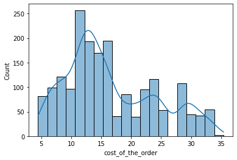

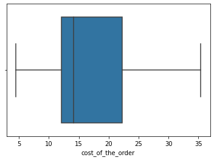

```python
# Write the code here
sns.histplot(data=df,x='cost_of_the_order', kde='True', stat ='count', bins = 20)
plt.show()

sns.boxplot(data=df,x='cost_of_the_order')
plt.show()
```

### Observations:

The cost of the order is right skewed. There is a slight peak at $24 and $29 while the costs decrease.

The boxplot shows the median cost is about $14 indicating a positively skewed costs having larger spreads above the median cost.

### Observation on food preparation Time

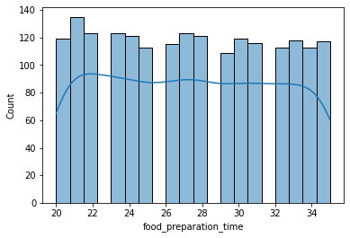

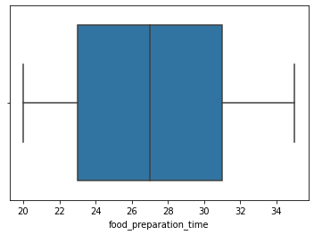

```python
sns.histplot(data=df,x='food_preparation_time', kde=True, stat ='count', bins = 20)
plt.show()

sns.boxplot(data=df,x='food_preparation_time')
plt.show()
```

### Observations:

The food preparation time is slightly evenly distributed and it takes about 20 and 35 minutes to prepare the food while the median is about 27 minutes.

### Observation on delivery time

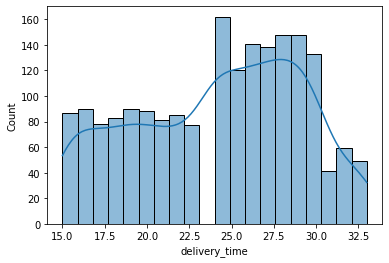

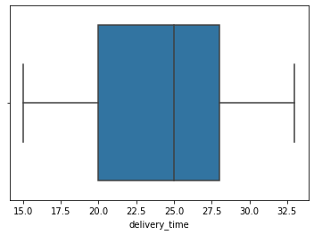

```python
sns.histplot(data=df,x ='delivery_time', kde='True', stat = 'count', bins = 20)
plt.show()
sns.boxplot(data=df,x='delivery_time')
plt.show()
```

### Observation on cuisine type

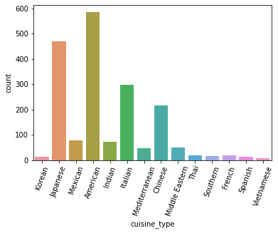

```python
sns.countplot(data=df,x='cuisine_type')
plt.xticks(rotation=70)
plt.show();
```

### Observations:

The most popular cuisines are American, Japanese, Italian, and Chinese accordingly.

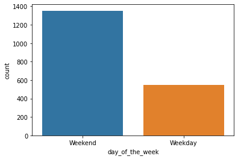

```python
sns.countplot(data=df,x='day_of_the_week')
plt.show();
```

### Observation:

The most orders were made on weekends.

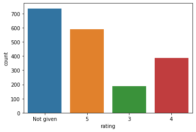

```python
sns.countplot(data=df,x='rating')
plt.show();
```

### Observations:

A significant amount of customers did not rate the orders, however, close to 600 orders were rated highest.

### **Question 7**: Which are the top 5 restaurants in terms of the number of orders received? [1 mark]

```python
# Write the code here
df[['restaurant_name','order_id']].groupby('restaurant_name').count().sort_values(by = 'order_id',axis = 0, ascending=False).head(5)
```

| restaurant_name | order_id |
| --- | --- |
| Shake Shack | 219 |
| The Meatball Shop | 132 |
| Blue Ribbon Sushi | 119 |
| Blue Ribbon Fried Chicken | 96 |
| Parm | 68 |

#### Observations:

The top five restaurants are shake shack, the meatball shop, blue ribbon sushi, blue ribbon fried chicken, and parm.

### **Question 8**: Which is the most popular cuisine on weekends? [1 mark]

```python
# Write the code here
df[df['day_of_the_week'] =='Weekend'].groupby('cuisine_type').count().sort_values(by = 'order_id',axis = 0, ascending=False).head(5)
```

| cuisine_type | order_id | customer_id | restaurant_name | cost_of_the_order | day_of_the_week | rating | food_preparation_time | delivery_time |
| --- | --- | --- | --- | --- | --- | --- | --- | --- |
| American | 415 | 415 | 415 | 415 | 415 | 415 | 415 | 415 |
| Japanese | 335 | 335 | 335 | 335 | 335 | 335 | 335 | 335 |
| Italian | 207 | 207 | 207 | 207 | 207 | 207 | 207 | 207 |
| Chinese | 163 | 163 | 163 | 163 | 163 | 163 | 163 | 163 |
| Mexican | 53 | 53 | 53 | 53 | 53 | 53 | 53 | 53 |

#### Observations:

The most popular cuisine on weekends is American.

### **Question 9**: What percentage of the orders cost more than 20 dollars? [2 marks]

```python
# Write the code here
total_observations = df['cost_of_the_order'].count()
# Do a count of orders with cost above $20
orders_above20 = df['cost_of_the_order'][df['cost_of_the_order']> 20].count()
percentage_above20 = round((orders_above20/total_observations)*100,2) # Rounded to two decimal places
percentage_above20
```

```
29.24
```

#### Observations:

Approximately 29.24% of the total orders cost more than 20 dollars

### **Question 10**: What is the mean order delivery time? [1 mark]

```python
# Write the code here
round(df['delivery_time'].mean(),2) # Rounded to two decimal places
```

```
24.16
```

#### Observations:

The average delivery time takes 24.16 minutes

### **Question 11:** The company has decided to give 20% discount vouchers to the top 3 most frequent customers. Find the IDs of these customers and the number of orders they placed. [1 mark]

```python
# Write the code here
df[['order_id','customer_id']].groupby('customer_id').count().sort_values(by = 'order_id',axis = 0, ascending=False).head(3)
```

| customer_id | order_id |
| --- | --- |
| 52832 | 13 |
| 47440 | 10 |
| 83287 | 9 |

#### Observations:

The top 3 customers with the most frequent order are above ( customer ID 52832. customer ID 47440, and customer ID 83287).

### **Question 12**: Perform a multivariate analysis to explore relationships between the important variables in the dataset. (It is a good idea to explore relations between numerical variables as well as relations between numerical and categorical variables) [10 marks]

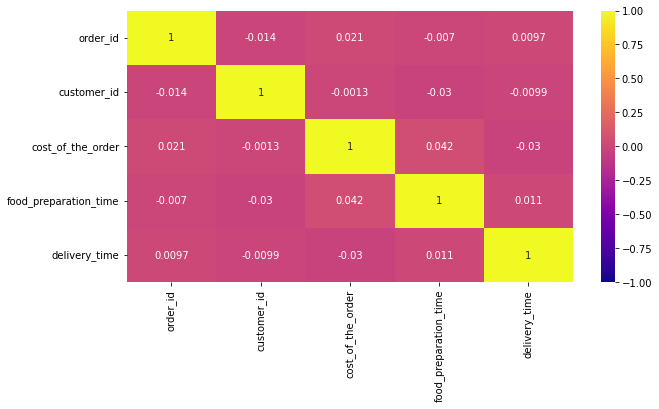

```python
# Write the code here
plt.figure(figsize=(10,5))
sns.heatmap(df.corr(),annot=True,cmap='plasma',vmin=-1,vmax=1)
plt.show()
```

### Observation:

There is a very weak correlation between the variables.

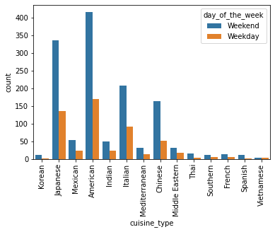

```python
sns.countplot(data=df,x='cuisine_type',hue= 'day_of_the_week')
plt.xticks(rotation=90)
plt.show()
```

### Observations:

The most cuisine types which are American, Japanese, Italian, and Chinese in that order were orders made on weekends. The pattern is similar for weekdays too, having American, Japanese, Italian and Chinese cusine accordingly being the most, although demand during weekdays are significantly less than weekends.

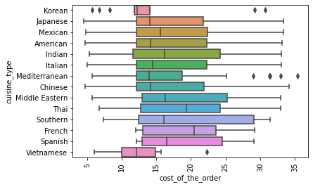

```python
sns.boxplot(data=df,x='cost_of_the_order',y='cuisine_type')
plt.xticks(rotation=90)
plt.show();
```

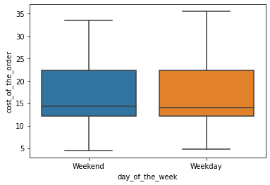

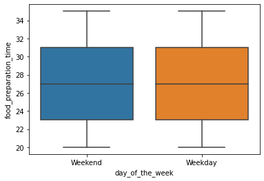

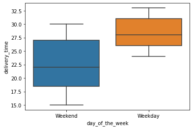

```python
sns.boxplot(data=df,x='day_of_the_week',y='cost_of_the_order')
plt.show()
sns.boxplot(data=df,x='day_of_the_week',y='food_preparation_time')
plt.show()
sns.boxplot(data=df,x='day_of_the_week',y='delivery_time')
plt.show()
```

Observation:

The median cost of order on weekend is slightly higher than weekdays.

It takes similar time to prepare the food acorss the restaurant on both weekends and weekdays.

The delivery time on weekdays takes longer as the median is about 28 minutes which is which is significantly closer to the maximum time it takes on weekends. The median delivery time on weekend is 22 minutes.

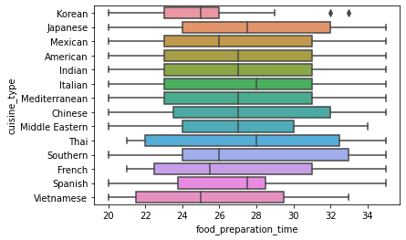

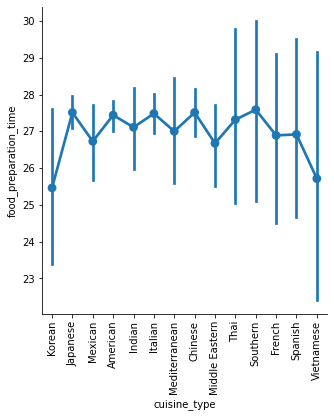

```python
sns.boxplot(data=df,x='food_preparation_time',y='cuisine_type')
plt.show()
sns.catplot(data = df, x = 'cuisine_type',y = 'food_preparation_time',kind = 'point')
plt.xticks(rotation=90)
plt.show();
```

### Observations:

Most cuisine types have more or less the same average preparation time between 25 and 28 minutes, although some have a larger spread of the 95% confidence interval.

### **Question 13:** The company wants to provide a promotional offer in the advertisement of the restaurants. The condition to get the offer is that the restaurants must have a rating count of more than 50 and the average rating should be greater than 4. Find the restaurants fulfilling the criteria to get the promotional offer. [3 marks]

```python
# Write the code here
#Create a data set of Restaurants with a consideration of mean rating greater than 4. The rating eliminates all unrated rows in calculating the mean
df2 = df[['restaurant_name','rating']][df['rating']!= 'Not given'].groupby('restaurant_name').mean()> 4
#..and reset the index
df2.reset_index(inplace=True)
# Create a data set of Restaurants with a consideration of count of rating greater than 50.Equally in this case unrated orders are not considered.
df3 = df[['restaurant_name','rating']][df['rating']!= 'Not given'].groupby('restaurant_name').count()> 50
#..and reset the index
df3.reset_index(inplace=True)
# Create a set of Restaurants that meet both conditions using merge
qualified_restaurants = pd.merge(df3[df3['rating']== True], df2[df2['rating']== True],on ='restaurant_name')
# Return the set of qualified restaurants only
qualified_restaurants
```

|  | restaurant_name | rating_x | rating_y |
| --- | --- | --- | --- |
| 0 | Blue Ribbon Fried Chicken | True | True |
| 1 | Blue Ribbon Sushi | True | True |
| 2 | Shake Shack | True | True |
| 3 | The Meatball Shop | True | True |

Observations: Four restaurant quailifies for the promotional offers.

### **Question 14:** The company charges the restaurant 25% on the orders having cost greater than 20 dollars and 15% on the orders having cost greater than 5 dollars. Find the net revenue generated by the company across all orders. [3 marks]

```python
# Write the code here
# Create a variable to hold the revenues
revenue = 0
income = 0
# Create a Pandas series of the cost of order column
cost = pd.Series(df['cost_of_the_order'])
# Loop through the series calculating the individual income component and adding it to the revenue variable
for i in range(len(cost)):
    if (cost[i] > 5) & (cost[i] < 20):
        income = cost[i]*0.15
    elif (cost[i] > 20):
        income = cost[i]*0.25
    else:
        income = 0
    revenue = revenue + income
```

```python
print('Net revenue generated is:',round(revenue,2),'assuming no cost charge for orders below $5')
```

```
Net revenue generated is: 6166.3 assuming no cost charge for orders below $5
```

#### Observations:

Food hub received US 6,166.3 dollars as commisson from the orders above $5 in total.

### **Question 15:** The company wants to analyze the total time required to deliver the food. What percentage of orders take more than 60 minutes to get delivered from the time the order is placed? (The food has to be prepared and then delivered.) [2 marks]

```python
# Write the code here
# Create a new column to hold the computed value for total time required
df['total_delivery_time'] = df['food_preparation_time']+df['delivery_time']
# Review to confirm the new column
df.head()
```

|  | order_id | customer_id | restaurant_name | cuisine_type | cost_of_the_order | day_of_the_week | rating | food_preparation_time | delivery_time | total_delivery_time |
| --- | --- | --- | --- | --- | --- | --- | --- | --- | --- | --- |
| 0 | 1477147 | 337525 | Hangawi | Korean | 30.75 | Weekend | Not given | 25 | 20 | 45 |
| 1 | 1477685 | 358141 | Blue Ribbon Sushi Izakaya | Japanese | 12.08 | Weekend | Not given | 25 | 23 | 48 |
| 2 | 1477070 | 66393 | Cafe Habana | Mexican | 12.23 | Weekday | 5 | 23 | 28 | 51 |
| 3 | 1477334 | 106968 | Blue Ribbon Fried Chicken | American | 29.20 | Weekend | 3 | 25 | 15 | 40 |
| 4 | 1478249 | 76942 | Dirty Bird to Go | American | 11.59 | Weekday | 4 | 25 | 24 | 49 |

```python
#Compute the percentage of orders taking more than 60 minutes
total_observations = df['total_delivery_time'].count()
ordertime_above60 = df['total_delivery_time'][df['total_delivery_time']> 60].count()

percent_above60 = round((ordertime_above60/total_observations)*100,2)
percent_above60
```

```
10.54
```

Observations: More than 10% of the orders take more than 60 minutes to get delivered from the time of ffod preparation to delivery.

### **Question 16:** The company wants to analyze the delivery time of the orders on weekdays and weekends. How does the mean delivery time vary during weekdays and weekends? [2 marks]

```python
# Write the code here
# The code computes the mean delivery time based on the day of the week, however it includes other statistics that maybe useful
# for review alongside the mean
avr_del_time = df.groupby('day_of_the_week')[['delivery_time']].agg(['mean','sum','count','std'])
avr_del_time
```

| day_of_the_week | delivery_time mean | delivery_time sum | delivery_time count | delivery_time std |
| --- | --- | --- | --- | --- |
| Weekday | 28.340037 | 15502 | 547 | 2.891428 |
| Weekend | 22.470022 | 30357 | 1351 | 4.628938 |

Observations: The average time for delivery on weekends is 22.47 minutes, while on weekdays it is 28.34 minutes. This finding is intriguing, particularly when considering the number of orders, which suggests that there are fewer orders on weekdays than on weekends. A possible explanation for this is that there is more traffic on weekdays than on weekends.